# HW3

Hakan Ekiz - IE360 - Fall2020

11.01.2021

## Introduction

In this project, the Vehicle Price Index dataset is used from EVDS. We will make manipulations and examinations on this dataset. Then, using different datasets as parameters, a model will be developed to estimate the vehicle price index. Data on USD / TL exchange rate, interest rate and the amount of money sent to the treasury from vehicles will be used. Finally, the estimated values and actual values on the model will be drawn on the graph and compared.

## Data

The Vehicle Index dataset is taken from EVDS. Date column is reorganized. The dataset is divided to study more clearly. Vehicleafter2015 dataset is created to work on which consists price index values after 2015.

First, let’s look at how this value has changed over time from a general perspective.

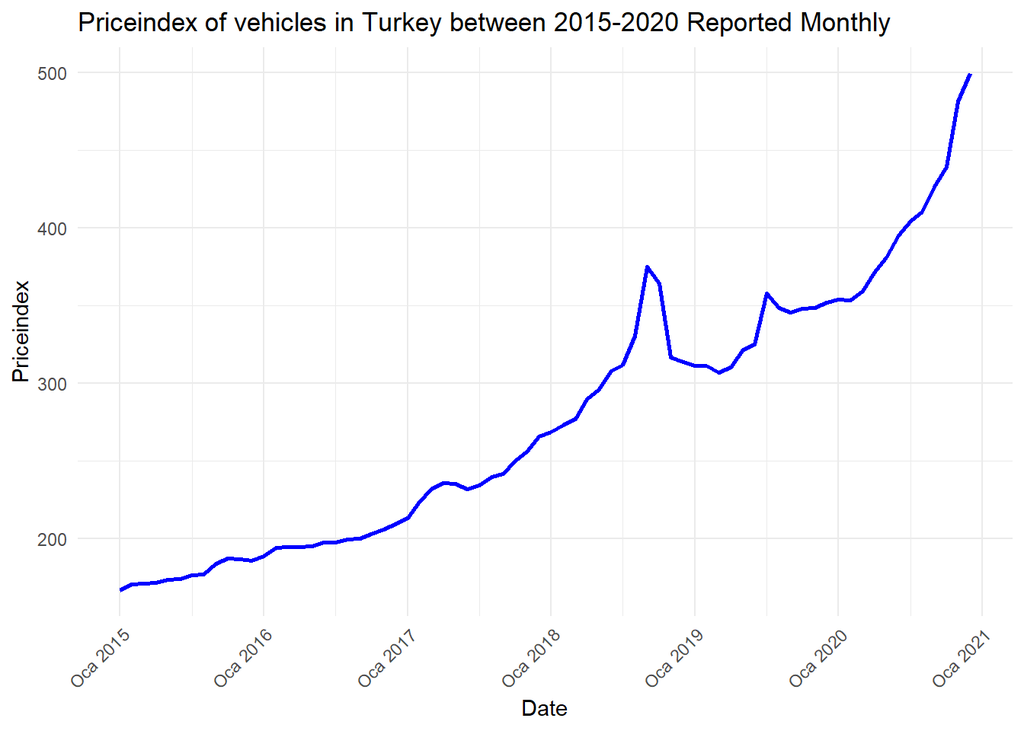

```r
ggplot(vehiclesafter2015, aes(x = Date, y = Priceindex)) +
  geom_line(size = 1, color="blue") +
  labs(title = "Priceindex of vehicles in Turkey between 2015-2020 Reported Monthly",
                             x = "Date",
                             y = "Priceindex") +
  theme_minimal() +
  theme(axis.text.x = element_text(angle = 45, hjust = 1))
```

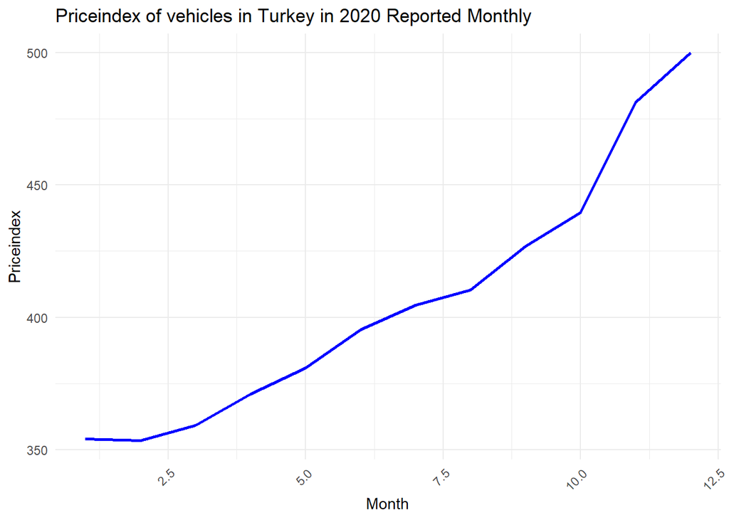

```r
ggplot(vehicles2020, aes(x = Month, y = Priceindex)) +
  geom_line(size = 1, color="blue") +
  labs(title = "Priceindex of vehicles in Turkey in 2020 Reported Monthly",
                             x = "Month",
                             y = "Priceindex") +
  theme_minimal() +
  theme(axis.text.x = element_text(angle = 45, hjust = 1))
```

## Forecasting

First, we look into the seasonality condition with months.

```r
summary(lm(Priceindex ~ as.factor(Month), vehiclesafter2015))
```

```
##
## Call:
## lm(formula = Priceindex ~ as.factor(Month), data = vehiclesafter2015)
##
## Residuals:
##      Min       1Q   Median       3Q      Max
## -118.583  -76.671   -7.775   55.255  195.407
##
## Coefficients:
##                    Estimate Std. Error t value Pr(>|t|)
## (Intercept)         250.513     36.665   6.833 4.82e-09 ***
## as.factor(Month)2     3.940     51.852   0.076    0.940
## as.factor(Month)3     6.413     51.852   0.124    0.902
## as.factor(Month)4    11.750     51.852   0.227    0.821
## as.factor(Month)5    16.648     51.852   0.321    0.749
## as.factor(Month)6    21.425     51.852   0.413    0.681
## as.factor(Month)7    29.975     51.852   0.578    0.565
## as.factor(Month)8    33.718     51.852   0.650    0.518
## as.factor(Month)9    45.087     51.852   0.870    0.388
## as.factor(Month)10   48.308     51.852   0.932    0.355
## as.factor(Month)11   48.910     51.852   0.943    0.349
## as.factor(Month)12   53.940     51.852   1.040    0.302
## ---
## Signif. codes:  0 '***' 0.001 '**' 0.01 '*' 0.05 '.' 0.1 ' ' 1
##
## Residual standard error: 89.81 on 60 degrees of freedom
## Multiple R-squared:  0.04832,    Adjusted R-squared:  -0.1262
## F-statistic: 0.2769 on 11 and 60 DF,  p-value: 0.988
```

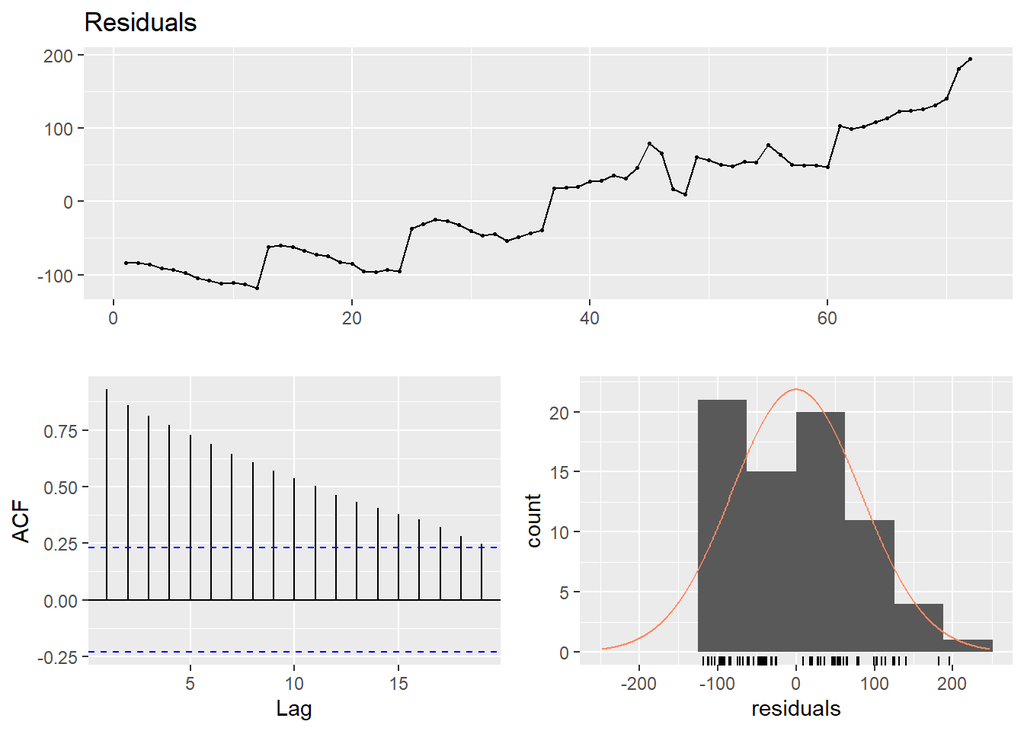

```
##
##  Breusch-Godfrey test for serial correlation of order up to 15
##
## data:  Residuals
## LM test = 68.505, df = 15, p-value = 8.236e-09
```

```r
checkresiduals(lm(Priceindex ~ as.factor(Month), vehiclesafter2015))
```

Because we have high standart error we should add other factors.

Now, we add dataset including Income of Turkey Treasury from vehicles.

```r
vehicleincome = read_xlsx("C:/Users/Z0047JBE/Desktop/dersler/IE360/HW3/hazine.xlsx")
vehiclesafter2015[,income :=as.double(unlist(vehicleincome[108:179,2]))]
```

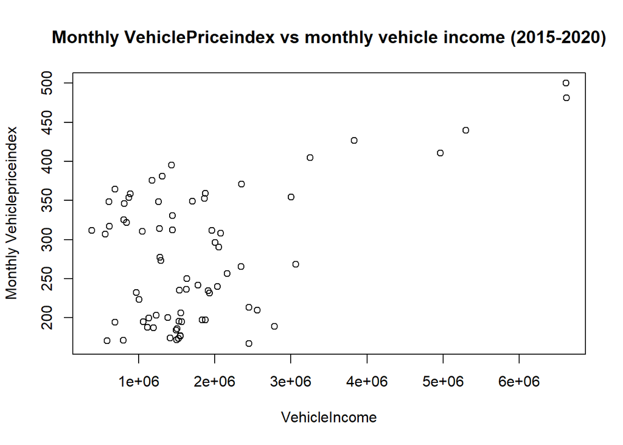

```r
plot(vehiclesafter2015$income, vehiclesafter2015$Priceindex,  xlab="VehicleIncome", ylab = "Monthly Vehiclepriceindex", main = "Monthly VehiclePriceindex vs monthly vehicle income (2015-2020)")
```

```r
summary(lm(Priceindex ~ as.factor(Month) + income, vehiclesafter2015))
```

```
##
## Call:
## lm(formula = Priceindex ~ as.factor(Month) + income, data = vehiclesafter2015)
##
## Residuals:
##      Min       1Q   Median       3Q      Max
## -102.320  -68.696   -9.913   72.347  129.452
##
## Coefficients:
##                     Estimate Std. Error t value Pr(>|t|)
## (Intercept)        1.519e+02  3.918e+01   3.876 0.000269 ***
## as.factor(Month)2  7.220e+01  4.799e+01   1.505 0.137746
## as.factor(Month)3  6.389e+01  4.725e+01   1.352 0.181451
## as.factor(Month)4  4.666e+01  4.609e+01   1.012 0.315469
## as.factor(Month)5  6.033e+01  4.648e+01   1.298 0.199307
## as.factor(Month)6  6.015e+01  4.625e+01   1.301 0.198425
## as.factor(Month)7  6.026e+01  4.592e+01   1.312 0.194501
## as.factor(Month)8  5.862e+01  4.575e+01   1.281 0.205078
## as.factor(Month)9  7.789e+01  4.601e+01   1.693 0.095760 .
## as.factor(Month)10 7.643e+01  4.585e+01   1.667 0.100821
## as.factor(Month)11 6.054e+01  4.548e+01   1.331 0.188225
## as.factor(Month)12 5.109e+01  4.540e+01   1.125 0.265002
## income             3.766e-05  8.580e-06   4.390 4.77e-05 ***
## ---
## Signif. codes:  0 '***' 0.001 '**' 0.01 '*' 0.05 '.' 0.1 ' ' 1
##
## Residual standard error: 78.63 on 59 degrees of freedom
## Multiple R-squared:  0.2826, Adjusted R-squared:  0.1367
## F-statistic: 1.937 on 12 and 59 DF,  p-value: 0.04777
```

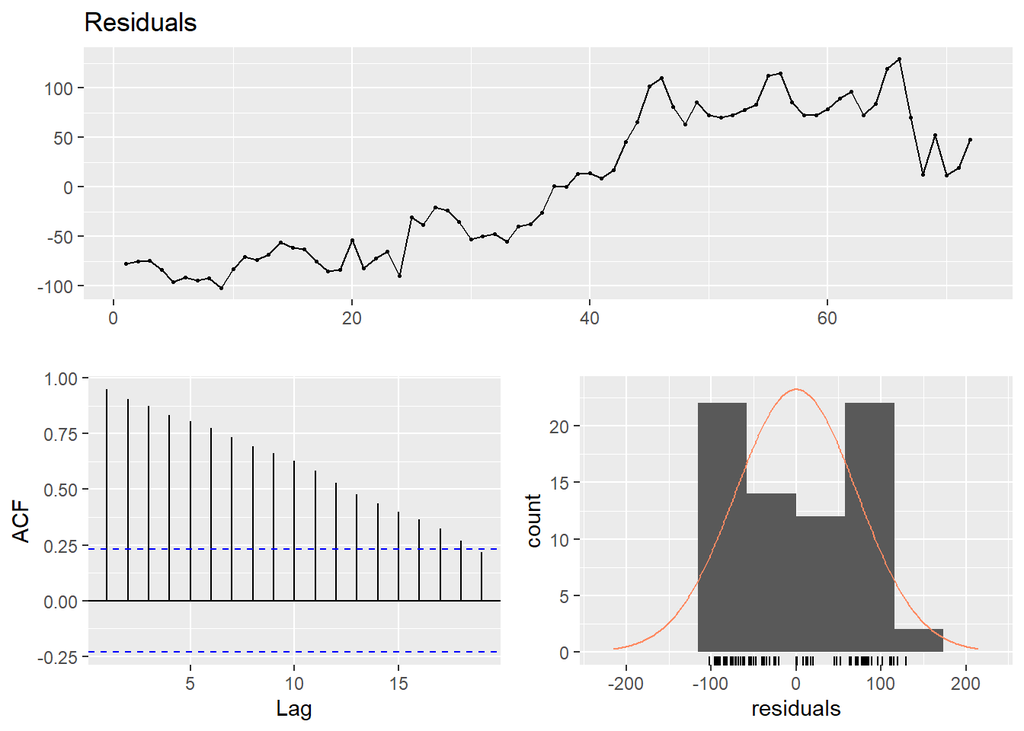

```
##
##  Breusch-Godfrey test for serial correlation of order up to 16
##
## data:  Residuals
## LM test = 66.294, df = 16, p-value = 4.406e-08
```

```r
checkresiduals(lm(Priceindex ~ as.factor(Month) + income, vehiclesafter2015))
```

The error rate is lower but still high.

Now, we add dataset including interest rate for purchasing cars.

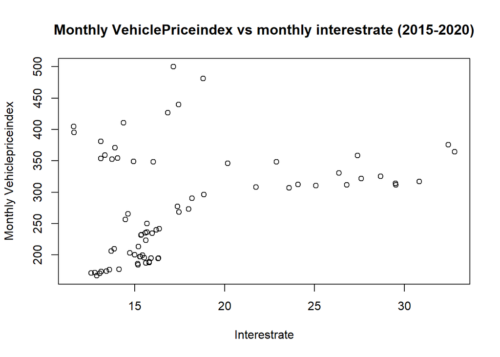

```r
interestrate = read_xlsx("C:/Users/Z0047JBE/Desktop/dersler/IE360/HW3/vehicleinterestrates.xlsx")
vehiclesafter2015[,interest :=as.double(unlist(interestrate[1:72,2]))]


plot(vehiclesafter2015$interest, vehiclesafter2015$Priceindex,  xlab="Interestrate", ylab = "Monthly Vehiclepriceindex", main = "Monthly VehiclePriceindex vs monthly interestrate (2015-2020)")
```

```r
summary(lm(Priceindex ~ as.factor(Month) + income + interest, vehiclesafter2015))
```

```
##
## Call:
## lm(formula = Priceindex ~ as.factor(Month) + income + interest,
##     data = vehiclesafter2015)
##
## Residuals:
##     Min      1Q  Median      3Q     Max
## -69.322 -39.960 -12.138   6.511 180.261
##
## Coefficients:
##                      Estimate Std. Error t value Pr(>|t|)
## (Intercept)        -1.926e+01  4.519e+01  -0.426   0.6716
## as.factor(Month)2   9.547e+01  3.971e+01   2.404   0.0194 *
## as.factor(Month)3   8.969e+01  3.916e+01   2.290   0.0256 *
## as.factor(Month)4   6.175e+01  3.802e+01   1.624   0.1098
## as.factor(Month)5   7.493e+01  3.833e+01   1.955   0.0554 .
## as.factor(Month)6   7.017e+01  3.809e+01   1.842   0.0706 .
## as.factor(Month)7   6.529e+01  3.779e+01   1.728   0.0893 .
## as.factor(Month)8   6.009e+01  3.764e+01   1.597   0.1158
## as.factor(Month)9   7.279e+01  3.786e+01   1.923   0.0594 .
## as.factor(Month)10  7.471e+01  3.772e+01   1.981   0.0524 .
## as.factor(Month)11  5.941e+01  3.741e+01   1.588   0.1177
## as.factor(Month)12  5.147e+01  3.735e+01   1.378   0.1735
## income              4.894e-05  7.360e-06   6.650 1.13e-08 ***
## interest            8.092e+00  1.498e+00   5.402 1.29e-06 ***
## ---
## Signif. codes:  0 '***' 0.001 '**' 0.01 '*' 0.05 '.' 0.1 ' ' 1
##
## Residual standard error: 64.68 on 58 degrees of freedom
## Multiple R-squared:  0.5228, Adjusted R-squared:  0.4158
## F-statistic: 4.887 on 13 and 58 DF,  p-value: 1.109e-05
```

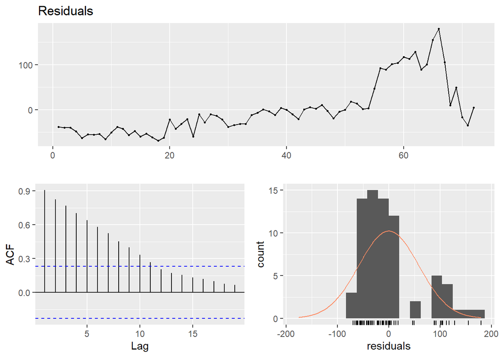

```
##
##  Breusch-Godfrey test for serial correlation of order up to 17
##
## data:  Residuals
## LM test = 66.789, df = 17, p-value = 7.645e-08
```

```r
checkresiduals(lm(Priceindex ~ as.factor(Month) + income + interest, vehiclesafter2015))
```

The error rate is lower

Now, we add dataset including USD/TL error rate. The increase of Dollar generally causes increase in prices.

```r
exchangerate = read_xlsx("C:/Users/Z0047JBE/Desktop/dersler/IE360/HW3/exchangerate.xlsx")
```

```
## * `` -> ...3
```

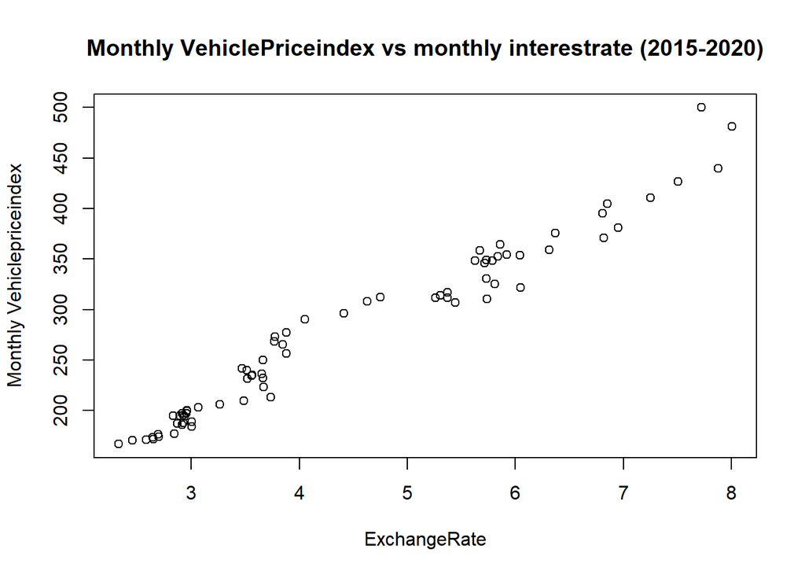

```r
vehiclesafter2015[,exchange :=as.double(unlist(exchangerate[1:72,2]))]


plot(vehiclesafter2015$exchange, vehiclesafter2015$Priceindex,  xlab="ExchangeRate", ylab = "Monthly Vehiclepriceindex", main = "Monthly VehiclePriceindex vs monthly interestrate (2015-2020)")
```

```r
summary(lm(Priceindex ~ as.factor(Month) + income + interest + exchange, vehiclesafter2015))
```

```
##
## Call:
## lm(formula = Priceindex ~ as.factor(Month) + income + interest +
##     exchange, data = vehiclesafter2015)
##
## Residuals:
##     Min      1Q  Median      3Q     Max
## -29.315 -10.730  -2.188  11.365  35.717
##
## Coefficients:
##                     Estimate Std. Error t value Pr(>|t|)
## (Intercept)        2.370e+01  1.155e+01   2.052  0.04473 *
## as.factor(Month)2  1.709e+01  1.042e+01   1.641  0.10636
## as.factor(Month)3  1.295e+01  1.027e+01   1.261  0.21249
## as.factor(Month)4  5.781e+00  9.824e+00   0.589  0.55851
## as.factor(Month)5  5.555e+00  1.000e+01   0.555  0.58076
## as.factor(Month)6  1.045e+01  9.868e+00   1.059  0.29410
## as.factor(Month)7  1.638e+01  9.721e+00   1.684  0.09756 .
## as.factor(Month)8  7.221e+00  9.709e+00   0.744  0.46005
## as.factor(Month)9  1.048e+01  9.830e+00   1.067  0.29069
## as.factor(Month)10 1.195e+01  9.798e+00   1.219  0.22780
## as.factor(Month)11 1.030e+01  9.629e+00   1.070  0.28934
## as.factor(Month)12 1.313e+01  9.556e+00   1.374  0.17471
## income             7.219e-06  2.353e-06   3.068  0.00329 **
## interest           7.219e-01  4.564e-01   1.582  0.11920
## exchange           4.856e+01  1.669e+00  29.091  < 2e-16 ***
## ---
## Signif. codes:  0 '***' 0.001 '**' 0.01 '*' 0.05 '.' 0.1 ' ' 1
##
## Residual standard error: 16.39 on 57 degrees of freedom
## Multiple R-squared:  0.9699, Adjusted R-squared:  0.9625
## F-statistic: 131.1 on 14 and 57 DF,  p-value: < 2.2e-16
```

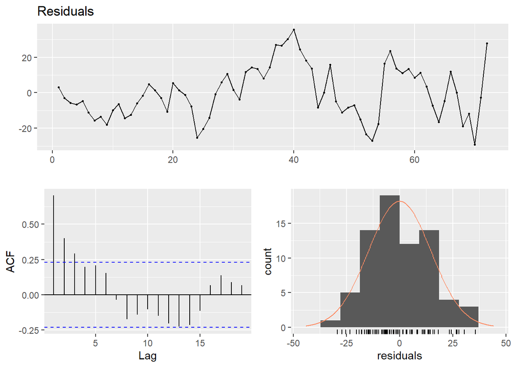

```
##
##  Breusch-Godfrey test for serial correlation of order up to 18
##
## data:  Residuals
## LM test = 54.276, df = 18, p-value = 1.662e-05
```

```r
checkresiduals(lm(Priceindex ~ as.factor(Month) + income + interest + exchange, vehiclesafter2015))
```

The dataset allows to decrease in error rate.

## Model

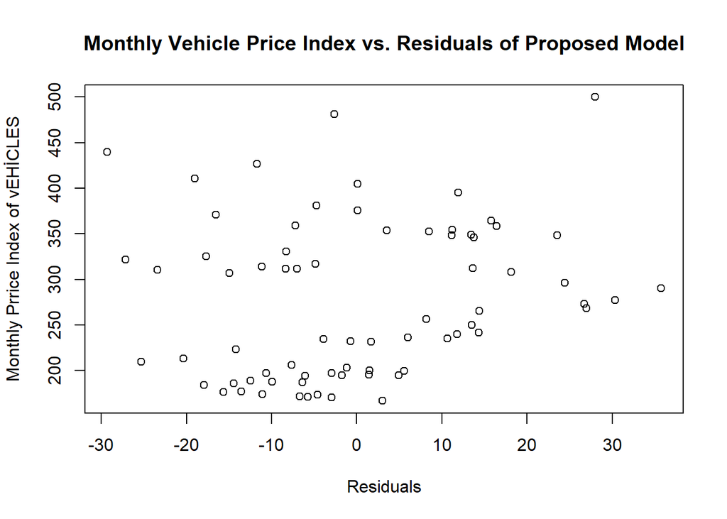

```r
model = lm(Priceindex ~ as.factor(Month) + income + interest + exchange, vehiclesafter2015)
vehiclesafter2015[,prediction:=fitted(model)]
vehiclesafter2015[,residual:=residuals(model)]

plot(vehiclesafter2015$residual, vehiclesafter2015$Priceindex, xlab="Residuals", ylab = "Monthly Prrice Index of vEHİCLES", main = "Monthly Vehicle Price Index vs. Residuals of Proposed Model")
```

Check the model with plotting predicted values and real values.

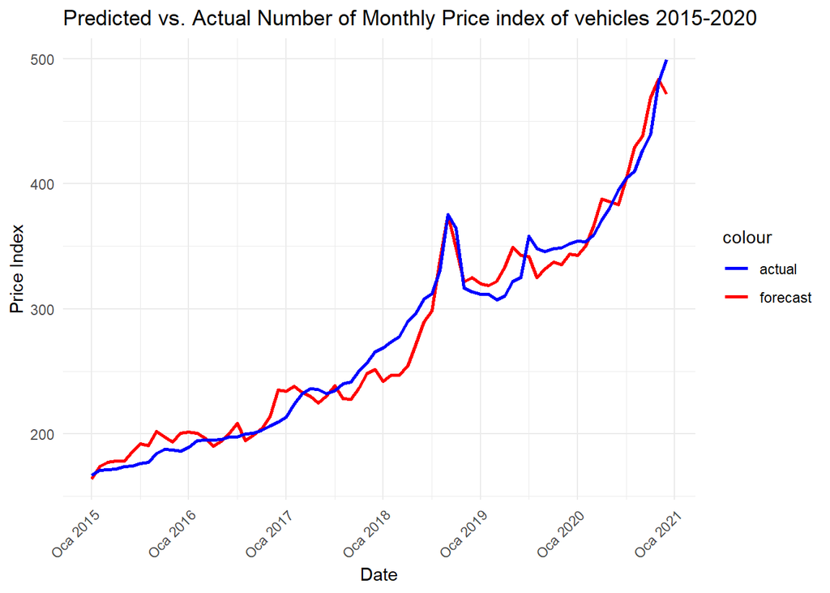

```r
cols = c("forecast" = "red", "actual" = "blue")
ggplot() +
  geom_line(data=vehiclesafter2015, aes(x=Date, y=prediction, colour="forecast"), lwd=1) +
  geom_line(data=vehiclesafter2015, aes(x=Date, y=Priceindex, colour="actual"), lwd=1) +
  labs(title = "Predicted vs. Actual Number of Monthly Price index of vehicles 2015-2020",
                             x = "Date",
                             y = "Price Index") +
  theme_minimal() +
  theme(axis.text.x = element_text(angle = 45, hjust = 1)) +
  scale_color_manual(values = cols)
```

## References

Dtasets are taken from EVDS.